# Dynamic Models Forecasting of Uber

In this notebook, I will explore the performance of the dynamic regression models. In particular, I will include the harmonics (Fourier terms) to model the seasonality. I will investigate the performance of the model and make the forecast for the year 2018.

```r
source('uber_data_preprocessing.R')
```

```r
source('error_metrics.R')
```

I will develop two different dynamic models. One with harmonics as xreg, and the other one with piecewise linear trend and harmonics as xreg. First, I will determine the best order (K) for Fourier terms for the models.

```r
# defining the best order (K) for fourier terms for the first model
bestfit <- list(aicc=Inf)
for(K in seq(25)) {
  xreg <- fourier(uber_train, K=K)
  fit <- auto.arima(uber_train, xreg=xreg,seasonal=FALSE)
  if(fit[["aicc"]] < bestfit[["aicc"]]) {
    bestfit <- fit
    bestK <- K
  }
}
print(bestK)
```

```
[1] 3
```

```r
# defining the best order (K) for fourier terms for the second model
bestfit <- list(aicc=Inf)
for(K in seq(25)) {
  t <- seq_along(uber_train)
  knot <- 141
  tb <- pmax(0,t-knot)
  xreg <- cbind(t,tb,fourier(uber_train, K=K))
  fit <- auto.arima(uber_train, xreg=xreg, seasonal=FALSE)
  if(fit[["aicc"]] < bestfit[["aicc"]]) {
    bestfit <- fit
    bestK <- K
  }
}
print(bestK)
```

```
[1] 3
```

As seen the best order of Fourier terms is the same for two cases. Now, I will build the model and fit them on the training data.

```r
# developing the first model
xreg1 <- fourier(uber_train, K=3)
dynamic_model1 <- auto.arima(uber_train, xreg=xreg1,seasonal=F, approximation = F, stepwise = F)
# developing the second model
t <- seq_along(uber_train)
knot <- 141
tb <- pmax(0,t-knot)
xreg2 <- cbind(t,tb,fourier(uber_train, K=3))
dynamic_model2 <- auto.arima(uber_train, xreg=xreg2, seasonal=F, approximation = F, stepwise = F)
```

```r
summary(dynamic_model1)
```

```
Series: uber_train
Regression with ARIMA(0,1,5) errors

Coefficients:
          ma1      ma2     ma3      ma4      ma5   drift    S1-52    C1-52   S2-52    C2-52   S3-52   C3-52
      -0.5385  -0.0977  0.2524  -0.1455  -0.1552  0.2986  -4.2207  -1.2811  1.9214  -1.7868  0.5493  1.4228
s.e.   0.0677   0.0777  0.0752   0.0700   0.0726  0.0915   1.2865   1.2891  0.8708   0.8630  0.7260  0.7189

sigma^2 estimated as 18.44:  log likelihood=-615.47
AIC=1256.94   AICc=1258.75   BIC=1300.82

Training set error measures:
                     ME     RMSE      MAE        MPE     MAPE      MASE         ACF1
Training set 0.01480578 4.163716 2.969428 0.09154117 5.930979 0.1452816 -0.008483704
```

```r
summary(dynamic_model2)
```

```
Series: uber_train
Regression with ARIMA(0,0,4) errors

Coefficients:
         ma1     ma2     ma3     ma4  intercept       t       tb    S1-52    C1-52   S2-52    C2-52   S3-52   C3-52
      0.3604  0.2149  0.4522  0.2399     7.0463  0.5241  -0.5844  -3.3622  -1.0206  1.9852  -1.7166  0.5382  1.4273
s.e.  0.0660  0.0635  0.0739  0.0665     1.4538  0.0161   0.0447   0.8630   0.8560  0.8110   0.8115  0.7500  0.7425

sigma^2 estimated as 16.81:  log likelihood=-607.8
AIC=1243.6   AICc=1245.68   BIC=1290.91

Training set error measures:
                      ME     RMSE      MAE       MPE     MAPE      MASE        ACF1
Training set -0.00571778 3.975525 2.894846 -0.384944 5.960887 0.1416326 0.002445251
```

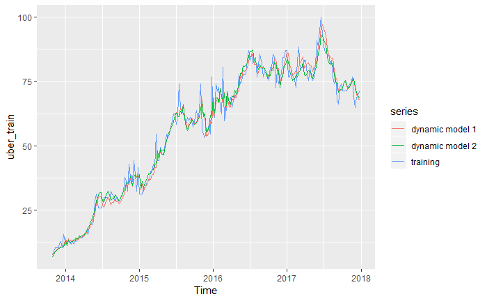

```r
autoplot(uber_train, series='training') +
autolayer(fitted(dynamic_model1), series='dynamic model 1')+
autolayer(fitted(dynamic_model2), series='dynamic model 2')
```

It seems that both models fit the data nicely. Let's take a look at the error metrics on training data.

```r
accuracy(dynamic_model1)
```

```
                     ME     RMSE      MAE        MPE     MAPE      MASE         ACF1
Training set 0.01480578 4.163716 2.969428 0.09154117 5.930979 0.1452816 -0.008483704
```

```r
accuracy(dynamic_model2)
```

```
                      ME     RMSE      MAE       MPE     MAPE      MASE        ACF1
Training set -0.00571778 3.975525 2.894846 -0.384944 5.960887 0.1416326 0.002445251
```

It seems that the dynamic model with piecewise linear trend and harmonics delivers a better fit to the training data. Let’s also see how both models perform on rolling based cross-validation.

```r
fdyn1 <- function(x,h){
    xreg <- fourier(x,K=2)
    xreg_new <- fourier(x,K=2, h=h)
    fit <- Arima(x, order=c(0,1,5), seasonal=c(0,0,0), xreg=xreg, include.drift = T)
    fcst <- forecast(fit, xreg=xreg_new, h=h)
    return(fcst)
}
fdyn2 <- function(x,h){
    t <- seq_along(x)
    knot <- 141
    tb <- pmax(0,t-knot)
    xreg <- cbind(t,tb,fourier(x, K=3))
    t_new <- t[length(t)] + seq(h)
    tb_new <- tb[length(tb)] + seq(h)
    xreg_new <- cbind(t_new, tb_new, fourier(x, K=3, h=h))
    fit <- Arima(x, order=c(3,0,2), seasonal=c(0,0,0), xreg=xreg)
    fcst <- forecast(fit, xreg=xreg_new, h=h)
    return(fcst)
}
```

```r
print(tsCV(uber_train, fdyn1, h=1) %>% window(start=c(2016,27)) %>% rmse())
```

```
[1] 4.784954
```

```r
print(tsCV(uber_train, fdyn2, h=1) %>% window(start=c(2016,27)) %>% rmse())
```

```
[1] 4.643928
```

Since the length of the two error series is not the same, I selected a window and then calculated the RMSE. As seen, the dynamic model with piecewise linear trend and harmonics of order 3 delivers a better cv RMSE as well. Hence, I will select this model as the top dynamic model. Now, let's take a look at the residual plots.

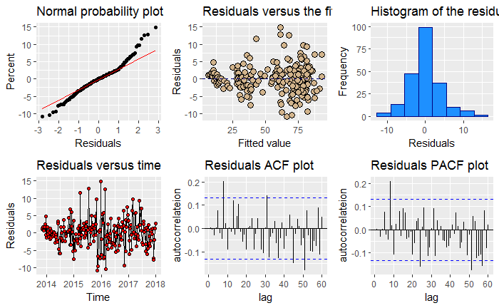

```r
residual_diagnostics_plots(dynamic_model2)
```

According to the residual plots:

1 - The residuals do not follow a normal distribution, suggesting that the confidence intervals may not be very accurate.

2 - Some structure could be seen in the residuals vs fitted value plot.

3- The variation in the residuals changes slightly over time.

4 - No significant spikes could be seen in the first 7 lags in ACF and PACF plots.

I believe this model explains the time-dependency in the data better than the others. However, the model does not satisfy all of the residual requirements. Let’s make the forecast for the year 2018.

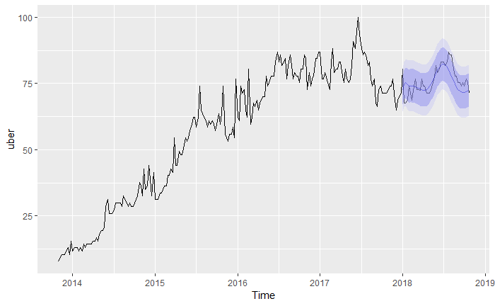

```r
h = length(uber_test)
t_new <- t[length(t)] + seq(h)
tb_new <- tb[length(tb)] + seq(h)
xreg_new <- cbind(t_new, tb_new, fourier(uber_train, K=3, h=h))
dynamic_model2_fcst <- forecast(dynamic_model2, xreg=xreg_new, h=h)
autoplot(uber)+
autolayer(dynamic_model2_fcst, alpha=0.4)
```

In fact, the model does a great job for forecasting the values in the year 2018. Let’s look at the error metrics.

```r
accuracy(dynamic_model2_fcst, uber)
```

```
                      ME     RMSE      MAE        MPE     MAPE      MASE        ACF1 Theil's U
Training set -0.00571778 3.975525 2.894846 -0.3849440 5.960887 0.1416326 0.002445251        NA
Test set      0.91354525 3.695966 2.864012  0.9702086 3.764207 0.1401241 0.519392237  1.113186
```